# Insectos acuáticos y su relación con variables fisicoquímicas en rios de Ecuador, Etiopia y Vietnam

## Objetivos

General

- Evaluar la relación entre variables fisicoquímicas y comunidades de insectos acuáticos en rios de Ecuador, Etiopia y Vietnam

Específicos

- Establecer disimilitudes en las comunidades de insectos acuáticos
- Determinar la influecia de la estacionalidad sobre las abundancias de insectos acuáticos
- Determinar la influencia de variables fisicoquímicas sobre la abundancia de insectos acuáticos

### Activando librerias a utilizar

```r
library(tidyverse)
library(car)
library(ggstatsplot)
library(vegan)
library(goeveg)
library(psych)
library(ggcorrplot)
library(factoextra)
library(performance)
```

### Filtrando la base de datos

```r
macroffqq <- read.csv("Bases/Abiotic_Preferences_of_Macroinvertebrates.csv")
```

```r
#Revisando estrutura de la base de datos
str(macroffqq)
View(macroffqq)
names(macroffqq)
```

```r
#Seleccionando solo las columnas con las abundancias
macro_abund <- macroffqq %>%
  select(18:23)

macro_abund[, 1:6] <- lapply(macro_abund[, 1:6], as.numeric)

## filtrar la base quitando las filas que tengan solo ceros
macro_abund <- macro_abund[rowSums(macro_abund[, 1:6]) > 0, ]

##filtrando la base original para que tenga las mismas dimensiones que la de abundancias
macroffqq2 <- macroffqq[rowSums(macroffqq[, 18:23]) > 0,]
```

## Análisis de escalamiento multidimensional no metrico NMDS

Con este análisis se establecieron las disimilitudes en las comunidades de macroinvertebrados acuáticos en rios de Ecuador Etiopia y Vietnam.

```r
#Explorando cuantas dimensiones debemos pedirle al NMDS
##generando el screeplot con los resultados del NMDS hasta 10 dimensiones

#library(goeveg)
# set.seed(123)
# dimcheckMDS(macro_abund, distance = "bray", k = 10)

#NMDS incial
set.seed(123)
nmds1 <- metaMDS(macro_abund, distance = "bray", k = 3)
```

```
Square root transformation
Wisconsin double standardization
*** Best solution was not repeated -- monoMDS stopping criteria:
     2: no. of iterations >= maxit
     5: stress ratio > sratmax
    13: scale factor of the gradient < sfgrmin
```

```r
##Revisar estres
nmds1$stress
```

```
[1] 0.09232332
```

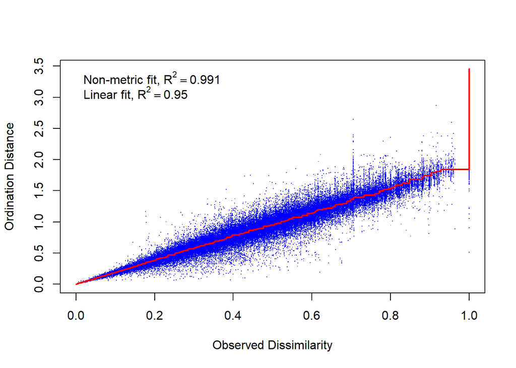

```r
##Diagrama de shepard
stressplot(nmds1)
```

El ajuste no metrico en el diagrama (R^2 = 0.991) fue bastante cercano a 1 por lo que la ordenación conserva muy bien la estructura original de las similitudes. Además, el ajuste lineal (R^2 = 0.95) es muy bueno y conserva bien las relaciones entre sitios.

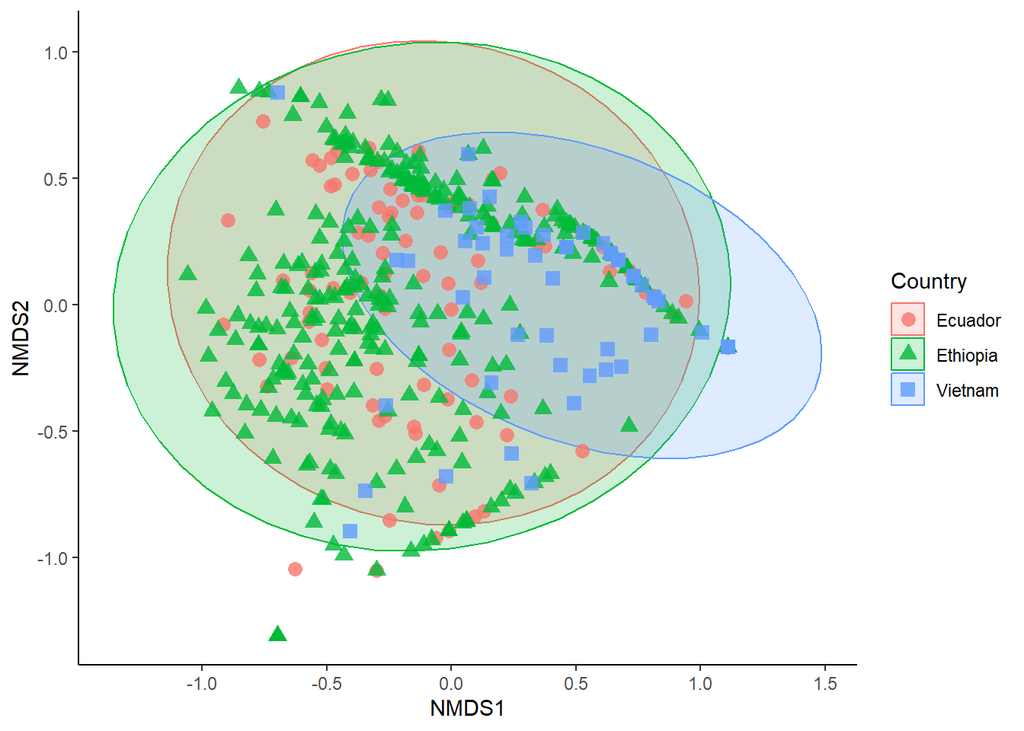

```r
##Crear el grafico
masterX::plot_mds(nmds1, meta_data = macroffqq2,
                  group_col = "Country",
                  overlay_type = "ellipses") +
  theme_classic()
```

El análisis NMDS indica que las comunidades de insectos acuáticos entre los paises de Etiopía y Ecuador son más parecidos entre si, y las comunidades de Vietnam presentan una diferenciación ligeramente más marcada. Además, entre Etiopía y Ecuador podría existir una mayor heterogeneidad en la composición, mientras que en Vietnam podría tener una menor variabilidad interna, sin embargo el eje NMDS1 podría indicar la existencia de un gradiente ambiental, esto podria ser representado por una o más variables que estarían estructurando las comunidades de insectos acuáticos.

## Análisis de componentes principales (PCA)

Con este análisis se determinó la influencia de la estacionalidad sobre las abundancias de insectos acuáticos

```r
macro_hell <- macro_abund %>%
  decostand("hellinger")


#¿las variables son mediciones continuas?
#View(macro_hell)

#¿Hay relaciones lineales entre las variables?
#En este caso se trata de una matriz de diversidad (abundancias) transformada por lo cual se acepta


##Realizando el test de esfericidad de bartlet
#H0: las variables son ortogonales (no correlacionadas)
#Ha: las variables no son ortogonales (hay correlacion)

mcor_macro <- cor(macro_hell, method = "kendall")
cortest.bartlett(mcor_macro, n = nrow(macro_hell))
```

```
$chisq
[1] 281.2933

$p.value
[1] 4.25627e-51

$df
[1] 15
```

La prueba de esfericidad de bartlet (p < 0.05, se rechaza la hipótesis nula) indico que hay una correlación significativa entre las abundancias de los insectos acuáticos. Por lo tanto es válido aplicar un PCA. Dicha correlación se puede apreciar en el siguiente grafico:

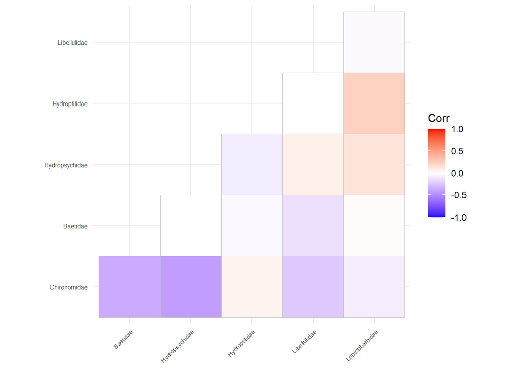

```r
##Revisando las correlaciones
#library(ggcorrplot)
cor_matrix <- cor(macro_hell, method = "kendall")
ggcorrplot(cor_matrix, tl.cex = 6, type = "lower")
```

La familia Letophlebiidae se correlaciona positivamente con Hydroptilidae e Hydropsychidae, otras correlaciones positivas ocurren entre las familias libellulidae y Hidrpsychidae, y entre Hydroptilidae y Chironomidae. En cambio la familia Baetidae se correlaciona negativamente con Chironomidae, lo mismo ocurre entre Hydrosychidae y Chironomidae.

```r
##tb-PCA con distancia de hellinger y estandariazación
macro_pca1 <- prcomp(macro_hell, scale = T, center = T)

summary(macro_pca1)
```

```
Importance of components:
                          PC1    PC2    PC3    PC4    PC5     PC6
Standard deviation     1.3534 1.1092 1.0724 0.9734 0.8320 0.38468
Proportion of Variance 0.3053 0.2051 0.1917 0.1579 0.1154 0.02466
Cumulative Proportion  0.3053 0.5103 0.7020 0.8600 0.9753 1.00000
```

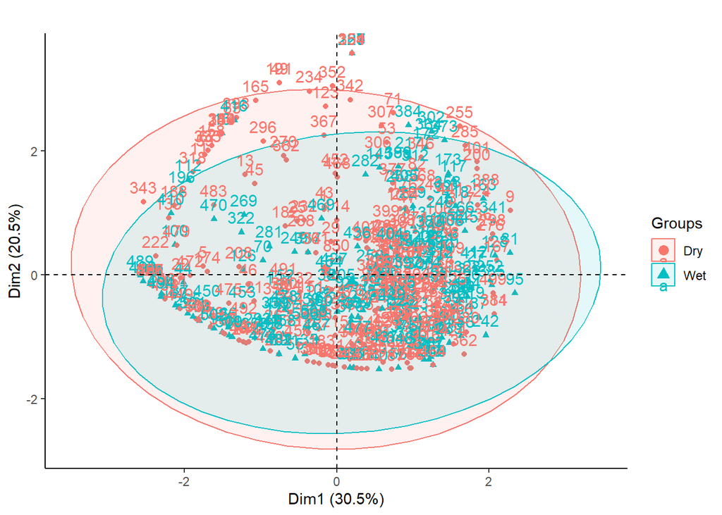

```r
library(factoextra)

fviz_pca_biplot(macro_pca1, title = "",
                geom.ind = c("text", "point"),
                geom.var = "none",
                habillage = macroffqq2$Season,
                addEllipses = TRUE) +
  theme_classic()
```

El PCA reflejó que no existe una diferenciación clara entre las estaciones seca y humeda con base en la composición de insectos acuáticos. esto podria indicar que las condiciones ambientales no cambian tanto como para generar un cambio en la composición de insectos acuáticos. Además, es importante señalar que la varianza explicada por los dos ejes suma más del 50%, lo cual no es un porcentaje tan alto, esto podría deberse a que la estructura de datos se reparte en más dimensiones.

## Análisis de redundancia (RDA)

Mediante este análisis se determinó la influencia de variables fisicoquimicas sobre la abundancia de insectos acuáticos

```r
##Eliminar valores faltantes de la base de datos macroffqq
macroffqq3 <- macroffqq %>% na.omit()

#str(macroffqq3)

##Matriz de abundacias
macro_abund2 <- macroffqq3 %>%
  select(18:23)

##Matriz de variables fisicoquímicas
macroffqq4 <- macroffqq3 %>%
  select(5:17)


##Creando un tb-RDA Saturado
RDA_saturado <- rda(macro_abund2 ~ ., data = macroffqq4, scale = TRUE)

##Resumen estadistico. del tb-RDA
#summary(RDA_saturado)

## Identificar colineriadad y creación del modelo mejorado
vif.cca(RDA_saturado) |> sort()
```

```
              BOD    Steam_Width2.4   Steam_Width1.85    Steam_Width4.2
         1.292484          1.536253          1.542630          1.546430
    Steam_Width33    Steam_Width9.3   Steam_Width7.15    Steam_Width0.8
         1.570654          1.573020          1.575941          1.578057
   Steam_Width1.3     Steam_Width14     Steam_Width31    Steam_Width2.8
         1.585099          1.595968          1.608323          1.616727
   Steam_Width8.5    Steam_Width5.2    Steam_Width5.4   Steam_Width2.43
         1.617464          1.625433          1.633618          1.633668
    Steam_Width35    Steam_Width0.7    Steam_Width6.5    Steam_Width3.9
         1.677390          1.686123          1.689273          1.692928
    Steam_Width50     Steam_Width13    Steam_Width5.6     Steam_Width22
         1.701180          1.702197          1.734726          1.791708
    Steam_Width18    Steam_Width2.7    Steam_Width3.7     Steam_Width30
         1.855725          1.867265          1.879708          1.905770
    Steam_Width25   Steam_Width10.8         Turbidity    Steam_Width1.8
         1.941948          1.955191          1.987271          2.052316
   Steam_Width7.2    Steam_Width1.6               NH4    Steam_Width1.7
         2.056935          2.066674          2.077408          2.084276
    Steam_Width43     Steam_Width21    Steam_Width1.5    Steam_Width3.8
         2.104343          2.122031          2.149131          2.165489
  Stream_Velocity    Steam_Width3.4 Water_temperature     Steam_Width15
         2.166808          2.219832          2.223348          2.228428
   Steam_Width1.2    Steam_Width3.5               NO3               PO4
         2.264558          2.283559          2.480497          2.517644
   Steam_Width5.5      Steam_Width2    Steam_Width3.6     Steam_Width38
         2.580251          2.614033          2.648096          2.701311
     Steam_Width1                pH     Steam_Width12      Stream_Depth
         2.747683          2.799630          2.821022          3.105918
     Conductivity      Steam_Width9     Steam_Width20    Steam_Width3.2
         3.192149          3.254020          3.270951          3.312564
           DO_sat           DO_conc    Steam_Width2.5      Steam_Width5
         3.420358          3.504701          4.175688          5.254874
     Steam_Width7      Steam_Width3     Steam_Width40     Steam_Width10
         5.628230          5.841916          6.139057          6.737968
     Steam_Width6      Steam_Width8      Steam_Width4
         7.173492          8.530753          9.251652
```

```r
## Creandon el tb-RDA sin la variable de ancho del rio
RDA1 <- rda(macro_abund2 ~ . -Steam_Width, data = macroffqq4, scale = TRUE)

##Creando tb-RDA con estep wise regression
RDA_step <- ordistep(RDA_saturado)
```

```
Start: macro_abund2 ~ Stream_Velocity + Stream_Depth + Steam_Width +      Water_temperature + Turbidity + pH + Conductivity + DO_conc +      DO_sat + BOD + NH4 + NO3 + PO4

                    Df    AIC      F Pr(>F)
- Turbidity          1 370.23 0.4643  0.790
- Steam_Width       59 321.45 0.8315  0.650
- Stream_Velocity    1 370.39 0.5581  0.630
- Stream_Depth       1 370.62 0.6951  0.625
- PO4                1 370.62 0.6997  0.575
- pH                 1 371.11 0.9868  0.440
- DO_sat             1 371.00 0.9239  0.405
- DO_conc            1 370.99 0.9201  0.390
- Water_temperature  1 371.48 1.2126  0.385
- NH4                1 371.32 1.1160  0.340
- Conductivity       1 372.61 1.8858  0.150
- BOD                1 373.61 2.4928  0.090 .
- NO3                1 374.02 2.7366  0.025 *
---
Signif. codes:  0 '***' 0.001 '**' 0.01 '*' 0.05 '.' 0.1 ' ' 1

Step: macro_abund2 ~ Stream_Velocity + Stream_Depth + Steam_Width +      Water_temperature + pH + Conductivity + DO_conc + DO_sat +      BOD + NH4 + NO3 + PO4

                    Df    AIC      F Pr(>F)
- Stream_Velocity    1 369.19 0.5769  0.750
- Steam_Width       59 320.69 0.8461  0.650
- Stream_Depth       1 369.35 0.6740  0.605
- PO4                1 369.40 0.7019  0.540
- DO_sat             1 369.63 0.8421  0.445
- DO_conc            1 369.78 0.9311  0.415
- NH4                1 370.03 1.0799  0.405
- pH                 1 370.00 1.0622  0.400
- Water_temperature  1 370.45 1.3313  0.240
- Conductivity       1 371.20 1.7880  0.150
- BOD                1 372.77 2.7437  0.085 .
- NO3                1 373.39 3.1245  0.055 .
---
Signif. codes:  0 '***' 0.001 '**' 0.01 '*' 0.05 '.' 0.1 ' ' 1

Step: macro_abund2 ~ Stream_Depth + Steam_Width + Water_temperature +      pH + Conductivity + DO_conc + DO_sat + BOD + NH4 + NO3 +      PO4

                    Df    AIC      F Pr(>F)
```

[output cut: 98 more lines]

```
- Conductivity  1 311.18 1.4914  0.130
- NH4           1 311.37 1.6796  0.115
- BOD           1 313.76 4.0480  0.040 *
- NO3           1 313.16 3.4498  0.025 *
---
Signif. codes:  0 '***' 0.001 '**' 0.01 '*' 0.05 '.' 0.1 ' ' 1

Step: macro_abund2 ~ BOD + NH4 + NO3

      Df    AIC      F Pr(>F)
- NH4  1 310.84 1.6361  0.100 .
- BOD  1 313.54 4.3186  0.055 .
- NO3  1 312.59 3.3666  0.025 *
---
Signif. codes:  0 '***' 0.001 '**' 0.01 '*' 0.05 '.' 0.1 ' ' 1
```

```r
## Revisando nuevamente la colinearidad
vif.cca(RDA1) |> sort(decreasing = TRUE)
```

```
          DO_conc            DO_sat                pH      Conductivity
         2.433483          2.379761          1.868736          1.681704
     Stream_Depth               NH4               NO3 Water_temperature
         1.495525          1.462903          1.357449          1.355723
  Stream_Velocity               PO4         Turbidity               BOD
         1.355034          1.292235          1.173658          1.105617
```

```r
##Creando el modelo nulo
RDA_nulo <-  rda(macro_abund2 ~ 1, data = macroffqq4, scale = TRUE)

summary(RDA_nulo)
```

```
Call:
rda(formula = macro_abund2 ~ 1, data = macroffqq4, scale = TRUE)

Partitioning of correlations:
              Inertia Proportion
Total               6          1
Unconstrained       6          1

Eigenvalues, and their contribution to the correlations

Importance of components:
                         PC1    PC2    PC3    PC4     PC5     PC6
Eigenvalue            1.7800 1.6289 1.0337 0.6902 0.52745 0.33973
Proportion Explained  0.2967 0.2715 0.1723 0.1150 0.08791 0.05662
Cumulative Proportion 0.2967 0.5682 0.7404 0.8555 0.94338 1.00000
```

```r
##Evaluando el modelo
RsquareAdj(RDA_step)$adj.r.squared
```

```
[1] 0.04513125
```

```r
rmse(RDA_step)
```

```
[1] 20.15331
```

```r
##Significancia del modelo
anova.cca(RDA_step, RDA_nulo)
```

```
Permutation tests for rda under reduced model
Permutation: free
Number of permutations: 999

Model 1: macro_abund2 ~ BOD + NH4 + NO3
Model 2: macro_abund2 ~ 1
  ResDf ResChiSquare Df ChiSquare      F Pr(>F)
1   172        5.631
2   175        6.000 -3    -0.369 3.7571  0.012 *
---
Signif. codes:  0 '***' 0.001 '**' 0.01 '*' 0.05 '.' 0.1 ' ' 1
```

```r
##Prueba de significancia por ejes
anova.cca(RDA_step, by = "axis")
```

```
Permutation test for rda under reduced model
Forward tests for axes
Permutation: free
Number of permutations: 999

Model: rda(formula = macro_abund2 ~ BOD + NH4 + NO3, data = macroffqq4, scale = TRUE)
          Df Variance      F Pr(>F)
RDA1       1   0.2466 7.5332  0.019 *
RDA2       1   0.1091 3.3330  0.070 .
RDA3       1   0.0133 0.4051  0.869
Residual 172   5.6310
---
Signif. codes:  0 '***' 0.001 '**' 0.01 '*' 0.05 '.' 0.1 ' ' 1
```

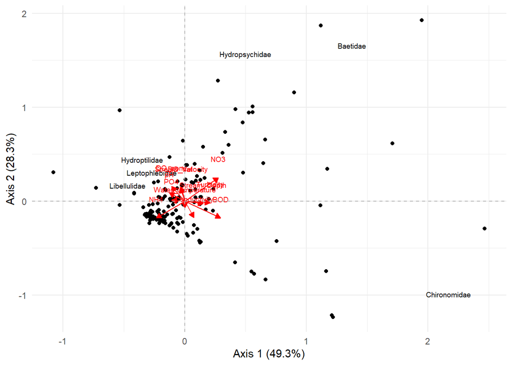

```r
##Graficación
masterX::plot_ordination(RDA1, scaling = 3,
                         segmentos_Yvar = TRUE)
```